# Chapter 4: Spatial Data Operations

Yifei Liu

9/7/2019

```r
library(tidyverse)
library(dplyr)
library(sf)
library(raster)
library(dplyr)
library(rcartocolor)
library(stringr) # for working with strings (pattern matching)
library(tidyr) # for unite() and separate()
library(spData)
```

## 4.1 Introduction

## 4.2 Spatial Operations on vectro data

### 4.2.1 Spatial subsetting

just like *attribute subsetting* in last chapter, you can use filter to subset data. But you can also use spatial subsetting to return all high point in the region

```r
canterbury <- nz %>%
  filter(Name == "Canterbury")

canterbury_height = nz_height[canterbury, ]
```

Various topological relations can be used for spatial subsetting.

```r
nz_height[canterbury, , op = st_disjoint]
```

```
## Simple feature collection with 31 features and 2 fields
## geometry type:  POINT
## dimension:      XY
## bbox:           xmin: 1204143 ymin: 5048309 xmax: 1822492 ymax: 5650492
## epsg (SRID):    2193
## proj4string:    +proj=tmerc +lat_0=0 +lon_0=173 +k=0.9996 +x_0=1600000 +y_0=10000000 +ellps=GRS80 +towgs84=0,0,0,0,0,0,0 +units=m +no_defs
## First 10 features:
##    t50_fid elevation                geometry
## 1  2353944      2723 POINT (1204143 5049971)
## 2  2354404      2820 POINT (1234725 5048309)
## 3  2354405      2830 POINT (1235915 5048745)
## 4  2369113      3033 POINT (1259702 5076570)
## 12 2363996      2759 POINT (1373264 5175442)
## 25 2364028      2756 POINT (1374183 5177165)
## 26 2364029      2800 POINT (1374469 5176966)
## 27 2364031      2788 POINT (1375422 5177253)
## 46 2364166      2782 POINT (1383006 5181085)
## 47 2364167      2905 POINT (1383486 5181270)
```

```r
nz_height[canterbury, 1, op = st_disjoint]
```

```
## Simple feature collection with 31 features and 1 field
## geometry type:  POINT
## dimension:      XY
## bbox:           xmin: 1204143 ymin: 5048309 xmax: 1822492 ymax: 5650492
## epsg (SRID):    2193
## proj4string:    +proj=tmerc +lat_0=0 +lon_0=173 +k=0.9996 +x_0=1600000 +y_0=10000000 +ellps=GRS80 +towgs84=0,0,0,0,0,0,0 +units=m +no_defs
## First 10 features:
##    t50_fid                geometry
## 1  2353944 POINT (1204143 5049971)
## 2  2354404 POINT (1234725 5048309)
## 3  2354405 POINT (1235915 5048745)
## 4  2369113 POINT (1259702 5076570)
## 12 2363996 POINT (1373264 5175442)
## 25 2364028 POINT (1374183 5177165)
## 26 2364029 POINT (1374469 5176966)
## 27 2364031 POINT (1375422 5177253)
## 46 2364166 POINT (1383006 5181085)
## 47 2364167 POINT (1383486 5181270)
```

see detail on op=, use ?Sf

```r
sel_sgbp = st_intersects(x = nz_height, y = canterbury)

class(sel_sgbp)
```

```
## [1] "sgbp"
```

```r
sel_logical = lengths(sel_sgbp) > 0
canterbury_height2 = nz_height[sel_logical, ]

canterbury_height3 <- nz_height %>%
  filter(st_intersects(x = ., y = canterbury, sparse = FALSE))
```

### 4.2.2 Topological relations

topological relations describe the spatial relationship between objects. To understand them, it helps to have some simple test data to work with.

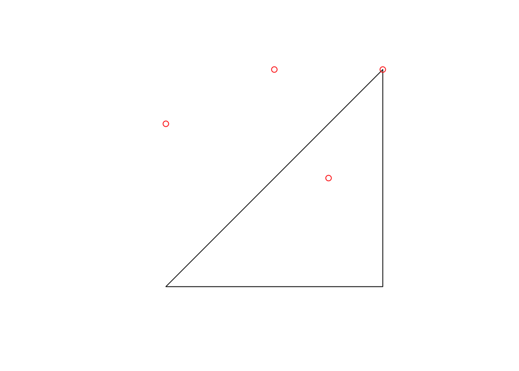

```r
# create a polygon
a_poly <- st_polygon(list(rbind(c(-1, -1), c(1, -1), c(1, 1), c(-1, -1))))
a = st_sfc(a_poly)

# create a line

l_line <- st_linestring(x = matrix(c(-1, -1, -0.5, 1), ncol = 2))
l = st_sfc(l_line)

# create points
p_multi <- st_multipoint(matrix(c(0.5, 1, -1, 0, 0, 1, 0.5, 1), ncol = 2))
p = st_cast(st_sfc(p_multi), "POINT")

plot(a)
plot(p, add = T, col = "red")
```

A simple query is: which of the points in p intersect in some way with polygon a?

```r
st_intersects(p, a) # p intersect in some way with a
```

```
## Sparse geometry binary predicate list of length 4, where the predicate was `intersects'
##  1: 1
##  2: 1
##  3: (empty)
##  4: (empty)
```

The sparse matrix output only registers a relation if one exists, reducing the memory requirments of topological operations on multi-feature objects.

```r
st_intersects(p, a, sparse = F)[, 1]
```

```
## [1]  TRUE  TRUE FALSE FALSE
```

the output is a matrix in which each row represents a feature in the target object and each column represent a feature in the selecting object. In this case, only first two featrues in p intersect with a and is only one feature in a so the result has only one column.

*st_within()* returns *TRUE* only for objects that are complete within the selecting objects. This applies only to the first object, which is inside the triangular polygon

```r
st_within(p, a, sparse = F)[, 1]
```

```
## [1]  TRUE FALSE FALSE FALSE
```

Note that although the first point is within the triangle, it does not touch any part of its border. For this reason *st_touch()* only retruns *TRUE* fro the second point

```r
st_touches(p, a, sparse = F)[, 1]
```

```
## [1] FALSE  TRUE FALSE FALSE
```

what about featrues that do not touch, but almost touch the selection object? use *st_is_within_distance()*

```r
st_is_within_distance(p, a, dist = 0.9, sparse = F)[, 1]
```

```
## [1]  TRUE  TRUE FALSE  TRUE
```